# BBall Season Presentation

Sam Eckhardt and Joey Miranda

Sunday, October 05, 2014

```r
library(XML)
library(ggmap)
library(ggplot2)
library(dplyr)
load("Gamestatisticscleaned.rda")
```

## The Data

The Data we have has been recieved from espn.com. It includes the season statistics for two conferences, the Big 12 and the West Coast Conference, from the season of 2001-2002 to the season of 2012-2013.

## Location of Teams With Points in Team Color

```r
# Where exactly are these cities on the US map? Let's plot
# the cities of these teams

location = c(-125, 24.207, -70, 50)  # It took a bit to figure these coordinates out - zoom to the appropriate location and level using openstreetmap.org
# and find coordinates from the export link

map = get_map(location = location, maptype = "roadmap", source = "google")
usmap = ggmap(map)
locs = geocode(as.character(unique(Gamestatistics$City)))
locs$City = unique(Gamestatistics$City)
Gamestatistics$lat = locs$lat[match(Gamestatistics$City, locs$City)]  # bring latitude and longitude information to main data frame
Gamestatistics$lon = locs$lon[match(Gamestatistics$City, locs$City)]

levels(Gamestatistics$Team)  # note the sequence of teams and arrange the colors in palette in corresponding sequence
```

[1] “Baylor Bears”  
[2] “Brigham Young Cougars”  
[3] “Gonzaga Bulldogs”  
[4] “Iowa State Cyclones”  
[5] “Kansas Jayhawks”  
[6] “Kansas State Wildcats”  
[7] “Loyola Marymount Lions”  
[8] “Oklahoma Sooners”  
[9] “Oklahoma State Cowboys”  
[10] “Pacific Tigers”  
[11] “Pepperdine Waves”  
[12] “Portland Pilots”  
[13] “Saint Mary’s Gaels”  
[14] “San Diego Toreros”  
[15] “San Francisco Dons”  
[16] “Santa Clara Broncos”  
[17] “TCU Horned Frogs”  
[18] “Texas Longhorns”  
[19] “Texas Tech Red Raiders”  
[20] “West Virginia Mountaineers”

[figure not shown]

```r
# The plot
teampalette <- c("#006600", "#FFFFFF", "#000099", "#990000",
    "#0000FF", "#6600CC", "#990033", "#660000", "#FF3300", "#FF6633",
    "#99CCFF", "#330099", "#99CC66", "#00CCFF", "#009900", "#999999",
    "#6633CC", "#FF9933", "#FF0000", "#FFFF00")


usmap + geom_point(data = Gamestatistics, aes(x = lon, y = lat,
    color = Team), size = 7) + ggtitle("Location of WCC and Big 12 Schools") +
    scale_color_manual(values = teampalette)  # add theme(legend.position='none') if you don't want the legend
```

[output not shown]

```r
ppgmean = Gamestatistics %>% group_by(Team, Year) %>% summarise(Mean.Points.Per.Game = mean(Points.Per.Game))

teampalette <- c("#006600", "#FFFFFF", "#000099", "#990000",
    "#0000FF", "#6600CC", "#990033", "#660000", "#FF3300", "#FF6633",
    "#99CCFF", "#330099", "#99CC66", "#00CCFF", "#009900", "#999999",
    "#6633CC", "#FF9933", "#FF0000", "#FFFF00")

levels(Gamestatistics$Team)
```

[1] “Baylor Bears”  
[2] “Brigham Young Cougars”  
[3] “Gonzaga Bulldogs”  
[4] “Iowa State Cyclones”  
[5] “Kansas Jayhawks”  
[6] “Kansas State Wildcats”  
[7] “Loyola Marymount Lions”  
[8] “Oklahoma Sooners”  
[9] “Oklahoma State Cowboys”  
[10] “Pacific Tigers”  
[11] “Pepperdine Waves”  
[12] “Portland Pilots”  
[13] “Saint Mary’s Gaels”  
[14] “San Diego Toreros”  
[15] “San Francisco Dons”  
[16] “Santa Clara Broncos”  
[17] “TCU Horned Frogs”  
[18] “Texas Longhorns”  
[19] “Texas Tech Red Raiders”  
[20] “West Virginia Mountaineers”

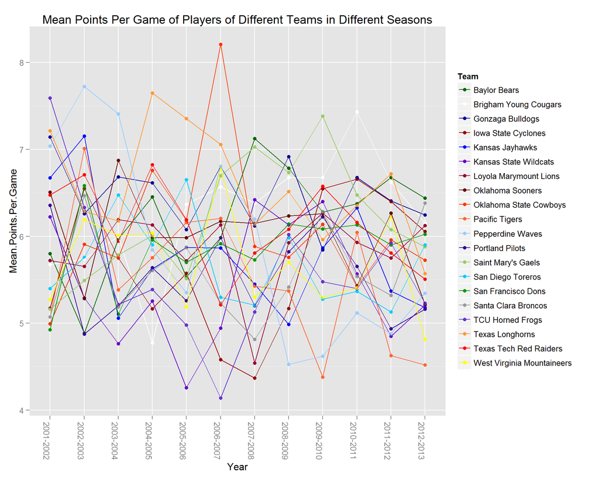

```r
# Plot
ggplot(ppgmean, aes(x = Year, y = Mean.Points.Per.Game, , color = Team,
    group = Team)) + geom_point() + geom_line() + theme(axis.text.x = element_text(angle = -90)) +
    ggtitle("Mean Points Per Game of Players of Different Teams in Different Seasons") +
    scale_color_manual(values = teampalette)
```

## Average Points Per Game of Players by WCC Teams in Different Seasons

```r
ppgmeanConf = Gamestatistics %>% group_by(Team, Year) %>% summarise(Mean.Points.Per.Game = mean(Points.Per.Game))

teampaletteWCC <- c("#FFFFFF", "#000099", "#990033", "#FF6633",
    "#99CCFF", "#330099", "#99CC66", "#00CCFF", "#009900", "#999999")

levels(Gamestatistics$Team)
```

[1] “Baylor Bears”  
[2] “Brigham Young Cougars”  
[3] “Gonzaga Bulldogs”  
[4] “Iowa State Cyclones”  
[5] “Kansas Jayhawks”  
[6] “Kansas State Wildcats”  
[7] “Loyola Marymount Lions”  
[8] “Oklahoma Sooners”  
[9] “Oklahoma State Cowboys”  
[10] “Pacific Tigers”  
[11] “Pepperdine Waves”  
[12] “Portland Pilots”  
[13] “Saint Mary’s Gaels”  
[14] “San Diego Toreros”  
[15] “San Francisco Dons”  
[16] “Santa Clara Broncos”  
[17] “TCU Horned Frogs”  
[18] “Texas Longhorns”  
[19] “Texas Tech Red Raiders”  
[20] “West Virginia Mountaineers”

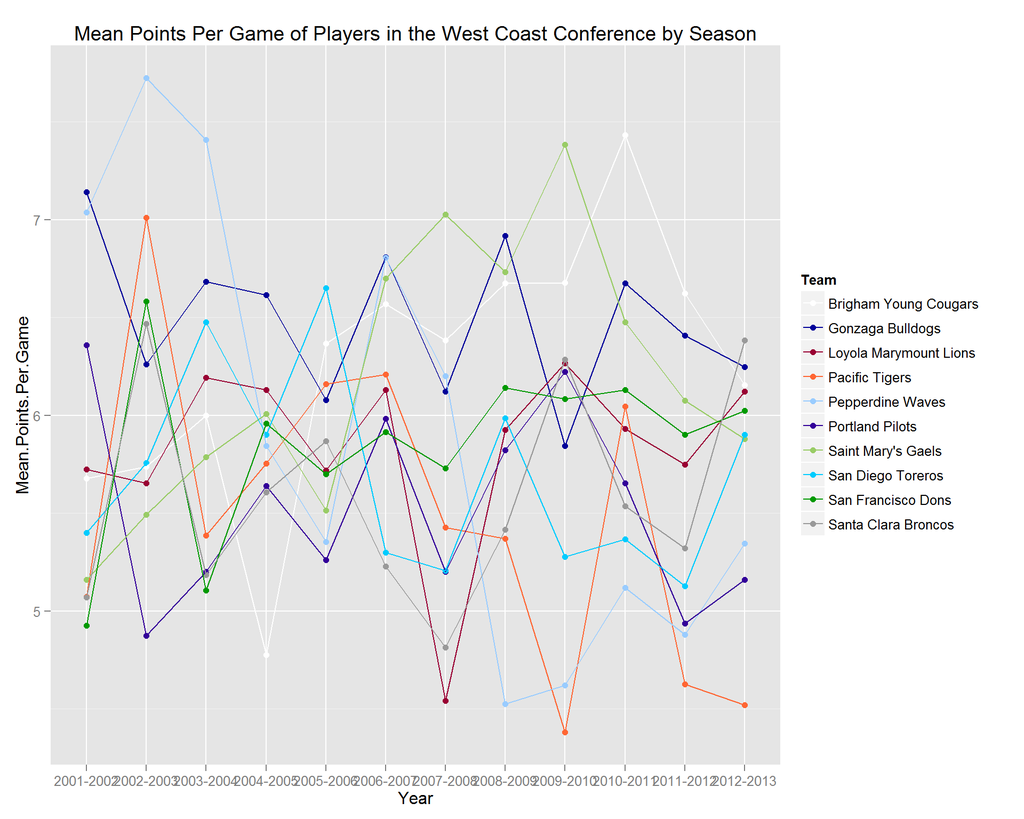

```r
ggplot(subset(ppgmeanConf, Team %in% c("Gonzaga Bulldogs", "Brigham Young Cougars",
    "Loyola Marymount Lions", "Saint Mary's Gaels", "San Francisco Dons",
    "Pepperdine Waves", "Pacific Tigers", "San Diego Toreros",
    "Portland Pilots", "Santa Clara Broncos", "")), aes(x = Year,
    y = Mean.Points.Per.Game, color = Team, group = Team)) +
    geom_point() + geom_line() + ggtitle("Mean Points Per Game of Players in the West Coast Conference by Season") +
    scale_color_manual(values = teampaletteWCC)
```

## Average Points Per Game of Players by Big 12 Teams in Different Seasons

```r
ppgmeanConf = Gamestatistics %>% group_by(Team, Year) %>% summarise(Mean.Points.Per.Game = mean(Points.Per.Game))

teampaletteB12 <- c("#006600", "#990000", "#0000FF", "#6600CC",
    "#660000", "#FF3300", "#6633CC", "#FF9933", "#FF0000", "#FFFF00")

levels(Gamestatistics$Team)
```

[1] “Baylor Bears”  
[2] “Brigham Young Cougars”  
[3] “Gonzaga Bulldogs”  
[4] “Iowa State Cyclones”  
[5] “Kansas Jayhawks”  
[6] “Kansas State Wildcats”  
[7] “Loyola Marymount Lions”  
[8] “Oklahoma Sooners”  
[9] “Oklahoma State Cowboys”  
[10] “Pacific Tigers”  
[11] “Pepperdine Waves”  
[12] “Portland Pilots”  
[13] “Saint Mary’s Gaels”  
[14] “San Diego Toreros”  
[15] “San Francisco Dons”  
[16] “Santa Clara Broncos”  
[17] “TCU Horned Frogs”  
[18] “Texas Longhorns”  
[19] “Texas Tech Red Raiders”  
[20] “West Virginia Mountaineers”

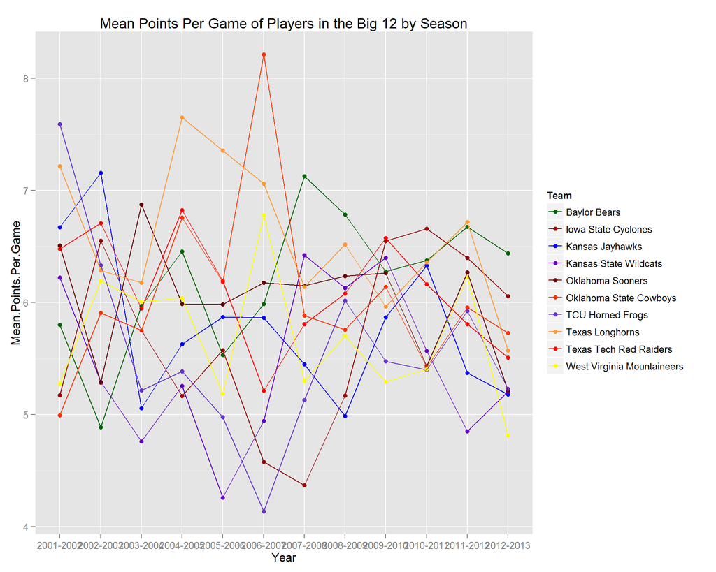

```r
ggplot(subset(ppgmeanConf, Team %in% c("Baylor Bears", "Kansas Jayhawks",
    "Kansas State Wildcats", "Oklahoma Sooners", "Oklahoma State Cowboys",
    "Texas Tech Red Raiders", "TCU Horned Frogs", "Texas Longhorns",
    "West Virginia Mountaineers", "Iowa State Cyclones", "")),
    aes(x = Year, y = Mean.Points.Per.Game, color = Team, group = Team)) +
    geom_point() + geom_line() + ggtitle("Mean Points Per Game of Players in the Big 12 by Season") +
    scale_color_manual(values = teampaletteB12)
```